# Visitor Survey Report: 2024 Season

Ann Arbor Summer Festival [(A2SF)](https://www.a2sf.org/) at Top of the Park

Vicky Wang (viwa@umich.edu)

## Background/Overview

- Cleaning and removal of potential bots from Post-Season survey results.
- Determination of best practices for data analysis
- Deep dive and results of zip codes - where are people from?
- Compare and contrast ages, gender, ethnic background between the two surveys
- Break out “What are your favorite offerings tonight?” By night. How do we compare/combine the data from the two surveys.
- Extrapolate age ranges for those who answered family offerings - who are they and can we reach out to them for more input?

### 1. Cleaning Post-Season Survey Data

*Remove non-US auto-collected countries and manual zip code entries that are not 5 characters.*

Rationale: Auto-collected countries outside of the United States is unlikely given the scope and target audience of the survey. Additional manual viewing row responses for non-US locations indicated bot behavior such as nonsensical free response answers. Zip code entries that are not 5 characters are unlikely, and few countries outside the US use postal codes.

First 6 Alphabetical Country-State Response Combinations

| Country Code | State | Number |
| --- | --- | --- |
| US | Alabama | 5 |
| US | Arizona | 13 |
| US | California | 37 |
| US | District Of Columbia | 4 |
| US | Florida | 7 |
| US | Illinois | 10 |

*Determine bots using zip code and state collected data.*

Rationale: Because some United States responses are also bots, we have to be creative to identify more bots further. To do this, I use a function to identify states and zip codes and determine whether the zip codes, which respondents manually inputted, match with the states/countries, which was automatically collected from respondents’ device locations.

| Respondent ID | State | Country Code | Bot |
| --- | --- | --- | --- |
| 304885124 | Alabama | US | Not Bot |
| 304885234 | Arizona | US | Not Bot |
| 304882108 | California | US | Not Bot |
| 304882174 | California | US | Not Bot |
| 304883063 | California | US | Not Bot |
| 304883546 | California | US | Not Bot |

*Determine unusually short duration survey response times.*

Rationale: Bots typically use short amounts of time to complete survey questions.

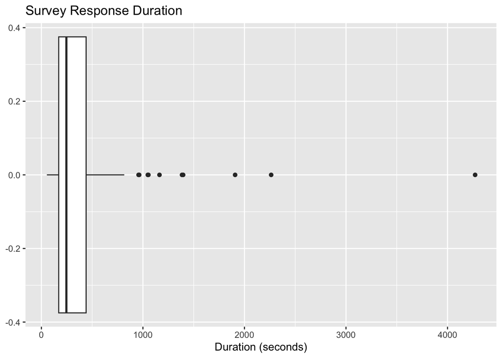

Takeaways: This boxplot indicates that no survey response was significantly shorter than the others. No bots were identified from this method.

*Manually identify any further responses as bots by examining free responses and determining whether any zip codes were “invalid” per this [link](https://www.unitedstateszipcodes.org/).*

Rationale: There is no straightforward method to determine further bots, as the remaining responses technically passed a variety of tests. Thus, the best practice is to manually analyze responses.

| Respondent ID | State | Zip Code | Free Response |
| --- | --- | --- | --- |
| 304677741 | Maryland | 21209 | Thank you! We were at Umich for a conference and decided to stop by. |
| 304675687 | Michigan | 48104 | keep up the good work! |
| 304675691 | Michigan | 48103 | A2SF is an amazing festival that I look forward to each year. |
| 304675732 | Michigan | 48108 | Loved salsa night |
| 304675914 | Michigan | 48103 | This is my favorite Ann Arbor event! |
| 304675950 | Michigan | 48104 | I enjoy performances by individuals who grew up here |

### 2. In-Season Survey Analysis

#### Where are visitors from?

*Understanding visitor origins by their manually collected zip codes.*

Rationale: non-5 digit zip codes were omitted, as it is difficult to determine the typing error committed to lead to an abnormal zip code. Additionally, collapsed all zip codes collected with count == 1 into an “Other” category in order to better visualize most common visitor homes.

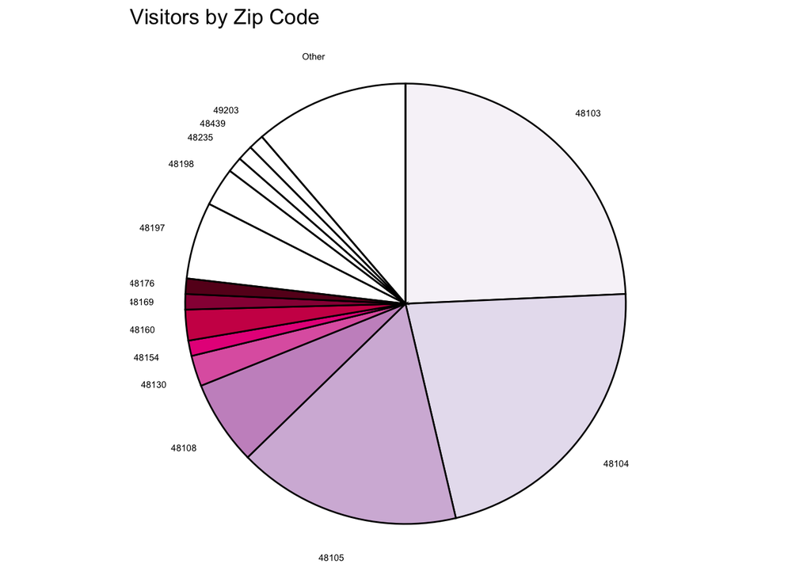

*Secondary data visualization method, mapping visitor hometowns.*

Rationale: Pie charts fail to visually assess distance and neighborhood from which participants traveled. Mapping is used to determine density and distance. First, use geocode() to add latitude and longitudes to the dataframe based on their zip code.

[interactive chart not shown]

*Visitors by home county.*

Although county data was not explicitly collected, we can extrapolate from zipcode data by using the zipcodeR package. This allows us to see zip code characteristics like population size, area in square miles, among other metadata.

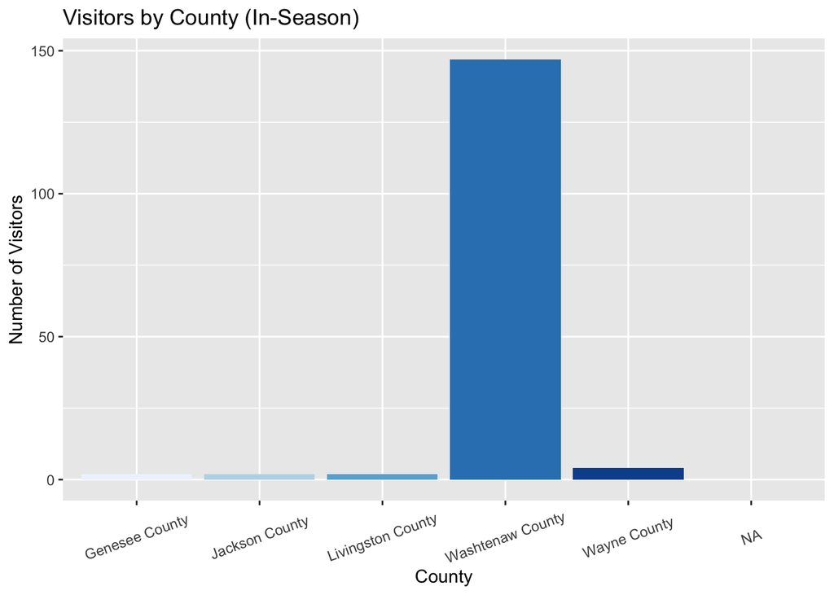

#### What ages are visitors?

*Bar graph of number of visitors by their selected age group.*

Visitor ages are re-ordered in chronological form and labels are shortened to promote figure readability. A significantly high number of visitors were between the ages of 18-24. This may be due to a variety of reasons, including: (1) survey canvassers were in this approximate range, (2) younger adults have higher technological proficiency, among other explanations.

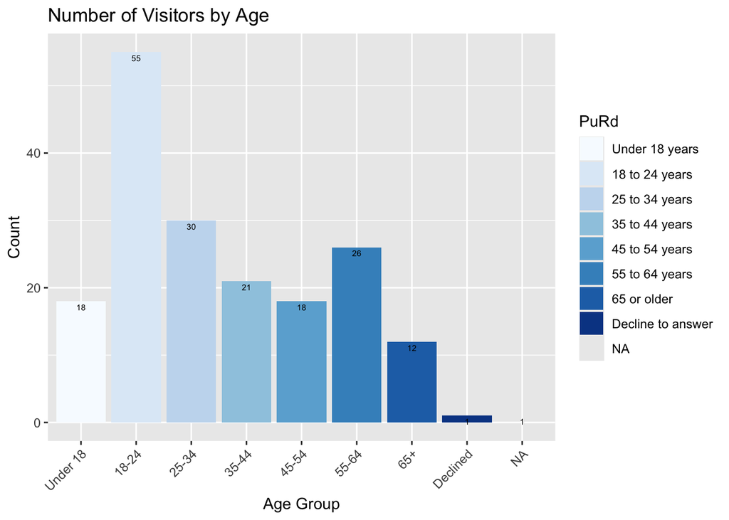